# Contents

1. Graph construction
2. Adjacency matrix
3. Drawing methods
4. File I/O

```python
import networkx as nx
import numpy as np
import matplotlib as mpl
import matplotlib.pyplot as plt
%matplotlib inline

nx.__version__, mpl.__version__
# other versions may give different results
```

```
('3.1', '3.5.2')
```

# 1. Graph construction

NetowrkX provides four basic classes for constructing graphs, viz. `Graph`, `DiGraph`, `MultiGraph`, and `MultiDiGraph`. The prefix `Di` marks a graph's directedness, and the prefix `Multi` allows the existence of multiple links between two nodes. We will only use `Graph` and `DiGraph` in this course.

`Graph` creates a **simple network**. You can add multiple nodes to it with `add_nodes_from` or add multiple edges to it with `add_edges_from`, for which an edge between nodes `u` and `v` is represented with the tuple `(u, v)`. You can add edges that link to non-existing nodes as NetworkX will automatically create the nodes.

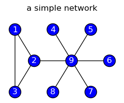

```python
S = nx.Graph()
S.add_edges_from([(1, 2), (1, 3), (2, 3),
                  (2, 9), (4, 9), (5, 9),  # node 9 is creaeted
                  (6, 9), (7, 9), (8, 9)]) # before 4, 5, 6, 7, 8

plt.figure(figsize=(3, 2))
plt.title('a simple network\n')
nx.draw(S, pos={1: (0, 1), 2: (1, 0), 3: (0,-1),
                4: (2, 1), 5: (4, 1), 6: (5, 0),
                7: (4,-1), 8: (2,-1), 9: (3, 0)},
        node_color='b', edgecolors='k',
        font_color='w', with_labels=True)
```

You can assess what nodes and edges a network contains by checking its attributes `nodes` and `edges`, which are dictionary-like objects. The nodes and the edges are ordered according to the sequence of their creation.

You can get the number of nodes or edges with `number_of_nodes` or `number_of_edges`. Alternatively, you can get the number of nodes by measuring the length of a network.

```python
print('S has %d nodes and %d edges.' % (
    S.number_of_nodes(), # same as len(S)
    S.number_of_edges()))

(S.nodes, # node 9 comes before 4, 5, 6, 7, 8
 S.edges)
```

```
S has 9 nodes and 9 edges.
```

```
(NodeView((1, 2, 3, 9, 4, 5, 6, 7, 8)),
 EdgeView([(1, 2), (1, 3), (2, 3), (2, 9), (9, 4), (9, 5), (9, 6), (9, 7), (9, 8)]))
```

In contrast, `DiGraph` creates a **directed network** in which `(u, v)` represents an edge from `u` to `v`.

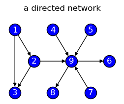

```python
D = nx.DiGraph()
D.add_edges_from([(1, 2), (1, 3), (2, 3),
                  (2, 9), (4, 9), (5, 9),
                  (7, 9), (9, 6), (9, 8)])

plt.figure(figsize=(3, 2))
plt.title('a directed network\n')
nx.draw(D, pos={1: (0, 1), 2: (1, 0), 3: (0,-1),
                4: (2, 1), 5: (4, 1), 6: (5, 0),
                7: (4,-1), 8: (2,-1), 9: (3, 0)},
        node_color='b', edgecolors='k',
        font_color='w', with_labels=True)
```

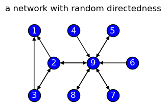

```python
S_directed = S.to_directed()

np.random.seed(5056)
actions = np.random.choice(3, S.number_of_edges())
for (u, v), a in zip(S.edges, actions):
    # a == 0: nothing happens
    # a == 1: reverse the edge
    # a == 2: add the opposite edge
    if a > 0:
        S_directed.add_edge(v, u)
        if a == 1:
            S_directed.remove_edge(u, v)

plt.figure(figsize=(3, 2))
plt.title('a network with random directedness\n')
nx.draw(S_directed, pos={1: (0, 1), 2: (1, 0), 3: (0,-1),
                         4: (2, 1), 5: (4, 1), 6: (5, 0),
                         7: (4,-1), 8: (2,-1), 9: (3, 0)},
        node_color='b', edgecolors='k',
        font_color='w', with_labels=True)
```

## 1.1 Attributes of a network

A network `G` is internally stored as something like a **three-layer dictionary**.

```
G[u][v][attr]
```

The first layer `u` specifies the source of edges; the second layer `v` specifies the target of an edge from `u`; the third layer `attr` specifies the attributes of the edge `(u, v)`. You can assign attributes like weights to edges easily by manipulating the network as a dictionary.

You can also assign attributes like colors to nodes. However, you cannot treat the network as a dictionary this time. You must work with its attribute `nodes`.

```python
S[1][2]['dept'] = 'MSDM'
S[2][9]['code'] = '5056'
S.nodes[2]['course'] = 'MSDM5056'

(S[2],            # about edges from node 2
 S[2][9],         # about the edge (2, 9)
 S.edges[(2, 9)], # also about the edge (2, 9)
 S.nodes[2])      # about node 2
```

```
(AtlasView({1: {'dept': 'MSDM'}, 3: {}, 9: {'code': '5056'}}),
 {'code': '5056'},
 {'code': '5056'},
 {'course': 'MSDM5056'})
```

Although `G[u]` is different from `G.nodes[u]`, you can interchange `G` and `G.nodes` when you iterate over them.

```python
print('Iteration over')
print('  - S.nodes gives: '+', '.join([str(node) for node in S.nodes]))
print('  - S       gives: '+', '.join([str(node) for node in S]))
```

```
Iteration over
  - S.nodes gives: 1, 2, 3, 9, 4, 5, 6, 7, 8
  - S       gives: 1, 2, 3, 9, 4, 5, 6, 7, 8
```

You can use `set_node_attributes` or `set_edge_attributes` when you need to add attributes to multiple nodes or edges. Conversely, you can check the attributes of all nodes or all edges via `nodes(data=attr)` or `edges(data=attr)`, where `attr` is the name of an attribute. By setting `data=True`, you will retrieve all the attributes. The attributes are returned as something like a list of tuples.

You can also save other general information about the network at its attribute `graph`.

```python
np.random.seed(5056)

nx.set_node_attributes(
    S, {node: color for node, color in zip(
        S, np.random.choice( ['c', 'y', 'm'], len(S) )
        )}, name='color')

nx.set_edge_attributes(
    S, {edge: weight for edge, weight in zip(
        S.edges, np.random.randint( 10, 50, S.number_of_edges() )/10
        )}, name='weight')

S.graph['pos'] = {1: (0, 1), 2: (1, 0), 3: (0,-1),
                  4: (2, 1), 5: (4, 1), 6: (5, 0),
                  7: (4,-1), 8: (2,-1), 9: (3, 0)}

(S.nodes(data='color'),  # like a list of 2-tuples
 S.edges(data='weight'), # like a list of 3-tuples
 S.graph)                # a dict
```

```
(NodeDataView({1: 'y', 2: 'y', 3: 'c', 9: 'm', 4: 'y', 5: 'c', 6: 'y', 7: 'm', 8: 'c'}, data='color'),
 EdgeDataView([(1, 2, 1.1), (1, 3, 3.0), (2, 3, 1.5), (2, 9, 3.8), (9, 4, 1.3), (9, 5, 1.4), (9, 6, 2.0), (9, 7, 2.1), (9, 8, 3.0)]),
 {'pos': {1: (0, 1),
   2: (1, 0),
   3: (0, -1),
   4: (2, 1),
   5: (4, 1),
   6: (5, 0),
   7: (4, -1),
   8: (2, -1),
   9: (3, 0)}})
```

Consequently, although there are no specific classes for weighted networks, you can create one by assigning weights to its edges.

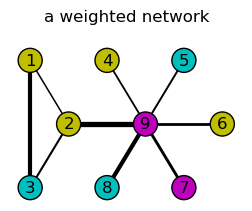

```python
weights = [w for u, v, w in S.edges(data='weight')]
colors = [c for n, c in S.nodes(data='color')]

plt.figure(figsize=(3, 2))
plt.title('a weighted network\n')
nx.draw(S, pos=S.graph['pos'], width=weights,
        node_color=colors, edgecolors='k', with_labels=True)
```

You can also use `add_weighted_edges_from` to add a weighted edge. The attribute is automatically named as `'weight'`.

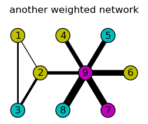

```python
W = nx.Graph()
W.add_weighted_edges_from([(1, 2, 1), (1, 3, 2), (2, 3, 3),
                           (2, 9, 4), (4, 9, 5), (5, 9, 6),
                           (6, 9, 7), (7, 9, 8), (8, 9, 9)])
weights = [w for u, v, w in W.edges(data='weight')]

plt.figure(figsize=(3, 2))
plt.title('another weighted network\n')
nx.draw(W, pos=S.graph['pos'], width=weights,
        node_color=colors, edgecolors='k',
        font_color='k', with_labels=True)
```

Finally, you can remove a node with `remove_nodes_from` or an edge `remove_edges_from`. When a node is removed, its associated edges are automatically removed altogether. When an edge is removed, its associated nodes are not removed.

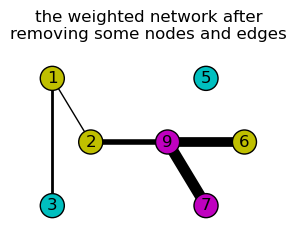

```python
W.remove_edges_from([(2, 3), (5, 9)])
W.remove_nodes_from([4, 8])
weights = [w for u, v, w in W.edges(data='weight')]
colors = [c for n, c in S.nodes(data='color') if n in W]

plt.figure(figsize=(3, 2))
plt.title('the weighted network after\nremoving some nodes and edges\n')
nx.draw(W, pos=S.graph['pos'], width=weights,
        node_color=colors, edgecolors='k',
        font_color='k', with_labels=True)
```

# 2. Adjacency matrix

You can retrieve a network's adjacency matrix $\mathbf{A}\equiv\left(A_{ij}\right)$ with `to_numpy_array`. The `i`th row and column in the adjacency matrix returned by `to_numpy_array(G)` correspond to the information of `list(G.nodes)[i]`.

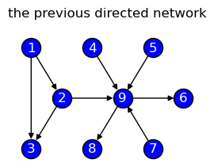

```
Given that list(D.nodes) = [1, 2, 3, 9, 4, 5, 7, 6, 8] ,
its adjacency matrix is
```

```
array([[0, 1, 1, 0, 0, 0, 0, 0, 0],
       [0, 0, 1, 1, 0, 0, 0, 0, 0],
       [0, 0, 0, 0, 0, 0, 0, 0, 0],
       [0, 0, 0, 0, 0, 0, 0, 1, 1],
       [0, 0, 0, 1, 0, 0, 0, 0, 0],
       [0, 0, 0, 1, 0, 0, 0, 0, 0],
       [0, 0, 0, 1, 0, 0, 0, 0, 0],
       [0, 0, 0, 0, 0, 0, 0, 0, 0],
       [0, 0, 0, 0, 0, 0, 0, 0, 0]])
```

```python
plt.figure(figsize=(3, 2))
plt.title('the previous directed network\n')
nx.draw(D, pos={1: (0, 1), 2: (1, 0), 3: (0,-1),
                4: (2, 1), 5: (4, 1), 6: (5, 0),
                7: (4,-1), 8: (2,-1), 9: (3, 0)},
        node_color='b', edgecolors='k',
        font_color='w', with_labels=True)
plt.show()

A = nx.to_numpy_array(D).astype(int)
print('Given that list(D.nodes) =', list(D.nodes), ',')
print('its adjacency matrix is')
A # A[i] and A[:, i] describe list(D.nodes)[i]
```

Conversely, you can construct a network from its adjacency matrix with `from_numpy_array`, in which you can specify the class of the network with `create_using`. The nodes are labelled one by one starting from 0. You can relabel them with `relabel_nodes`.

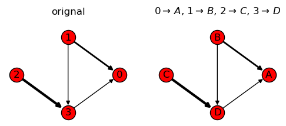

```python
A = np.array([[0, 0, 0, 0],
              [2, 0, 0, 1],
              [0, 0, 0, 3],
              [1, 0, 0, 0]])
G = nx.from_numpy_array(A, create_using=nx.DiGraph)
weights = [w for u, v, w in G.edges(data='weight')]
# the values of the adjacency matrix
# are automatically interpreted as 'weight'

plt.figure(figsize=(6, 2))
plt.subplot(121)
plt.title('orignal\n')
nx.draw_circular(G, node_color='r', edgecolors='k',
                 width=weights, with_labels=True)

G = nx.relabel_nodes(G, {n: chr(n+65) for n in G})
plt.subplot(122)
plt.title(', '.join([r'$%d\rightarrow\,%s$' % (i, n)
                     for i, n in enumerate(G)])+'\n')
nx.draw_circular(G, node_color='r', edgecolors='k',
                 width=weights, with_labels=True)
```

**Pay attention to a directed network's adjacency matrix**: $A_{ij}=1$ represents an edge **from $i$ to $j$** in NetworkX, while some resources define it to be an edge from $j$ to $i$.

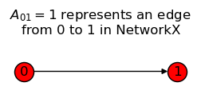

```
The adjacency matrix of this network is
```

```
array([[0, 1],
       [0, 0]])
```

```python
G = nx.DiGraph([(0, 1)])

plt.figure(figsize=(3, 1))
plt.title(r'$A_{01}=1$'+' represents an edge\nfrom 0 to 1 in NetworkX')
nx.draw(G, pos={0: (0, 0), 1: (1, 0)},
        node_color='r', edgecolors='k', with_labels=True)
plt.show()

print('The adjacency matrix of this network is')
A = nx.to_numpy_array(G).astype(int)
A # only A[0, 1] = 1
```

# 3. Drawing methods

NetworkX provides [many methods for drawing graphs](https://networkx.org/documentation/stable/reference/drawing.html), among which `draw` is the basic one. You will probably need to use parameters like

- `pos` (the **layout**, i.e. a dictionary of the nodes' coordinates),
- `node_size`,
- `node_color`,
- `linewidths` (width of the nodes' borders),
- `edgecolors` (colour of the nodes' borders),
- `width` (width of the network's edges),
- `edge_color` (colour of the network's edges),
- `with_labels` (showing the nodes' names or not), and
- `font_color`.

(Pay extra attention to the frustrating underscores and plural forms.)

You can observe how they are used on the following toy network: every integer between 10 and 30 becomes a node, and two integers are connected if they share a common factor greater than 2.

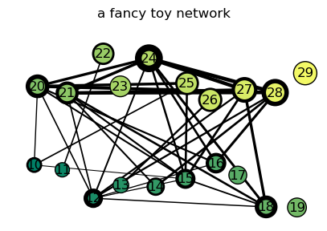

```python
toy = nx.Graph()
toy.add_nodes_from(range(10, 30))
factors = {n: [f for f in range(3, n+1) if n%f==0] for n in toy}
for u in toy:
    for v in range(min(toy), u):
        if len(set(factors[u]).intersection(
            set(factors[v]))) > 0: toy.add_edge(u, v)

np.random.seed(5056)
plt.figure(figsize=(5, 3))
plt.title('a fancy toy network\n')
nx.draw(toy,
        pos={n: (n% 10+(np.random.random()-.5)/2,
                 n//10+(np.random.random()-.5)/2) for n in toy},
        node_size=[15*n for n in toy],
        node_color=[mpl.cm.summer((n-min(toy))/len(toy)) for n in toy],
        linewidths=[len(factors[n]) for n in toy],
        width=[(u*v)/200 for u, v in toy.edges],
        edgecolors='k', with_labels=True)
```

If you do not specify `pos`, the nodes will be placed at random, resulting in a rather messy graph.

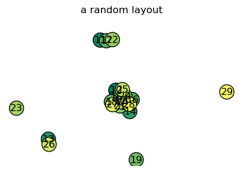

```python
np.random.seed(5056)
plt.figure(figsize=(5, 3))
plt.title('a random layout\n')
nx.draw(toy, node_color=[mpl.cm.summer((n-min(toy))/len(toy)) for n in toy],
        edgecolors='k', with_labels=True)
```

On the contrary, it is no way easy to think of a layout that avoids overlapping nodes and edges. If you do not have any ideas, it may be not bad to place the nodes in a circle with `draw_circular`; however, the layout becomes quite incomprehensible once there are many nodes.

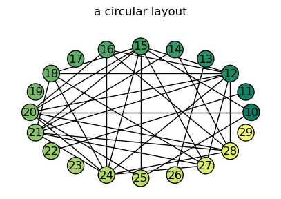

```python
plt.figure(figsize=(5, 3))
plt.title('a circular layout\n')
nx.draw_circular(
    toy, node_color=[mpl.cm.summer((n-min(toy))/len(toy)) for n in toy],
    edgecolors='k', with_labels=True)
```

I prefer to use `draw_kamada_kawai` instead, which places the nodes according to the [Kamada-Kawai algorithm](https://www.sciencedirect.com/science/article/abs/pii/0020019089901026). The result usually looks pretty nice in my opinion. (Just remember: *Kawaii!*)

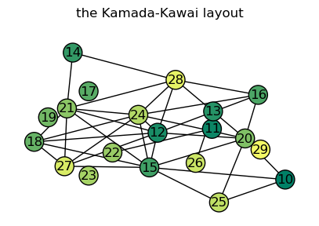

```python
plt.figure(figsize=(5, 3))
plt.title('the Kamada-Kawai layout\n')
nx.draw_kamada_kawai(
    toy, node_color=[mpl.cm.summer((n-min(toy))/len(toy)) for n in toy],
    edgecolors='k', with_labels=True)
```

You can also adjust their coordinates by using `kamada_kawai_layout` and `draw` explicitly.

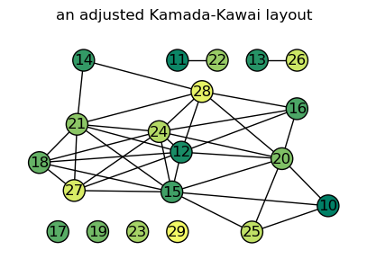

```python
kamada_kawai = nx.kamada_kawai_layout(toy)
for i, n in enumerate([11, 22, 13, 26]):
    kamada_kawai[n] = [.2*i, 1]
for i, n in enumerate([17, 19, 23, 29]):
    kamada_kawai[n] = [-.6+.2*i, -.85]

plt.figure(figsize=(5, 3))
plt.title('an adjusted Kamada-Kawai layout\n')
nx.draw(toy, pos=kamada_kawai,
        node_color=[mpl.cm.summer((n-min(toy))/len(toy)) for n in toy],
        edgecolors='k', with_labels=True)
```

As you keep practising, you will see that NetworkX performs quite awfully in visualization despite its excellence in calculation. It will take you much time to fix your code so that your graphs look slightly better.

If you really want to draw something beautiful, you may need other tools like [Gephi](https://gephi.org/).

# 4. File I/O

NetworkX can export a network object to [various kinds of files](https://networkx.org/documentation/stable/reference/readwrite/index.html). We are going to use the **GML format**, which stands for "graph modelling language". It is a common format to represent a network in plain text.

Suppose you have created a network `G`:

```
G = nx.Graph()
    G.add_edge('pi', 3)
    G.nodes[3]['prec'] = 2.71828
    G['pi'][3]['attr'] = 'pie'
```

you can use `write_gml` to convert it to a GML file that stores

```
graph [ node [ id 0 label "pi" ]
            node [ id 1 label "3" prec 2.71828 ]
            edge [ source 0 target 1 attr "pie" ] ]
```

(The actual file looks a bit different because of indentation.) Note that

- every node is assigned an integer `id` starting from 0, while its original name is saved as its `label`;
- a node's `label` is definitely a **string** even if it has a numeric name originally; and
- an edge is represented with its two ends' `id`.

```python
for n in toy:
    toy.nodes[n]['x'] = kamada_kawai[n][0]
    toy.nodes[n]['y'] = kamada_kawai[n][1]
nx.write_gml(toy, 'datasets/toy.gml')
```

You can convert a GML file back to a network object with `read_GML`. By default, NetworkX names the nodes of an imported network with their `label` instead of `id`.

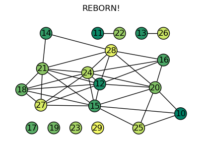

```python
del toy
toy = nx.read_gml('datasets/toy.gml')
toy = nx.relabel_nodes(toy, {n: int(n) for n in toy})

plt.figure(figsize=(5, 3))
plt.title('REBORN!\n')
nx.draw(toy, pos={n: tuple(toy.nodes[n].values()) for n in toy},
        node_color=[mpl.cm.summer((n-min(toy))/len(toy)) for n in toy],
        edgecolors='k', with_labels=True)
```